# Discan

Paolo Provero

# 1 The frequency of somatic mutations in cancer is positively associated with involvement in genetic disease

## 1.1 Variables

In order to assess whether the frequency of cancer somatic mutations of a gene is a predictor of the involvement of the gene in genetic diseases, we used logistic regression, with the response variable being the association of the gene to “abnormal phenotype” (HP:0000118) or any of its descendants in the Human Phenotype Ontology, having first removed all annotations to the HPO term “neoplasm” (HP:0002664) and to all its descendants. The logistic model involved as independent variables, besides the variable of interest (number of patients with a somatic mutations in all the TCGA samples) a series of potential confounders, namely gene features associated to the mutability of the gene sequence, as detailed below. Moreover, we included the evolutionary age of each gene, that has been shown to be associated to both genetic disease involvement [1] and cancer-relevant mutations [2].

The total frequency of TCGA somatic mutations of a gene was defined as the number of patients with one or more somatic mutations in the gene classified as *Frame_Shift_Del*, *Frame_Shift_Ins*, *In_Frame_Del*, *In_Frame_Ins*, *Missense_Mutation*, *Nonsense_Mutation*, *Silent*, *Splice_Site* and *Translation_Start_Site*. Somatic mutations were obtained with the RTCGAToolbox package. The evolutionary age of a gene was obtained from the oldest phylostratum in which the gene appeared, from Table S1 of [3]. Note that the phylostrata are indicated by integers, with a smaller values indicating older evolutionary age. The phylostrata were considered as numeric variables.

The genomic features associated with gene mutability were similar to the ones used in (see e.g. [4]), and specifically:

- CDS length (1 variable): total length of the CDS according to the TxDb.Hsapiens.UCSC.hg19.knownGene Bioconductor package
- DNASE accessibility (2 variables): fraction of the gene region (or the CDS) that overlaps a DHS peak in the “clustered” Encode dataset (wgEncodeRegDnaseClusteredV3.bed). The overlap with the gene region and the CDS were treated as two separate variables.
- Histone marks (6 variables): fraction of the gene region (or the CDS) that overlaps a peak of *H3k4me1*, *H3k4me3* and *H3k27ac*. The peaks were obtained from the following cells *Gm12878*, *H1hesc*, *Hsmm*, *Huvec*, *K562*, *Nhek* and *Nhlf* from the Encode broad peaks. For each histone mark, peaks from all cells were merged.
- Lamin B1 association (1 variable): fraction of the gene region overlapping lamin B1-associated domains in Tig3 cells from the corresponding UCS track
- Replication timing (1 variable): replication timing by repli-chip from ENCODE/FSU averaged over the gene region for the following cell lines: *Bg02es*, *Gm06990*, *H1hesc*, *H7es*, *H9es*, *Helas3*, *Imr90* and *Ipshfib2ips4*, then averaged over the cells
- Nucleosome positioning (2 variables): nucleosome signal from *Gm12878* and *K562* cells, averaged over the gene (or the CDS) region, then averaged between the two cell lines
- Transcription (1 variable): pooled RNA-seq signal for the cell lines *Gm12878*, *H1hesc*, *Hsmm*, *Huvec*, *K562*, *Nhek* and *Nhlf* averaged over the gene region and then over the cell lines
- Repeat (2 variables): fraction of the gene region (or of the CDS) that overlaps a simple repeat according to the corresponding UCSC track
- Trinucleotide frequencies (64 variables): frequency of each trinucleotide in the CDS (“TTT” removed to avoid collinearity in multivariable logistic regression). The CDS sequence was obtained from TxDb.Hsapiens.UCSC.hg19.knownGene

Note that GC content is a linear function of the the trinucleotide frequencies and thus was not included in the covariates.

## 1.2 Univariable analysis

We first used univariable regression analysis to evaluate the association between each independent variable and the response. Out of 82 variables, 52 were nominally (P<0.05) associated to the response. The top 10 by P-value are shown in the table (all variables were standardized, therefore the coefficient refers to one unit of standard deviation).

| predictor | beta_uni | P_uni |
| --- | --- | --- |
| occ_total_sum | 0.6514 | 1.539e-274 |
| nsome_cds | 0.5201 | 9.212e-173 |
| H3k4me1_cds | 0.4222 | 1.261e-132 |
| H3k27ac_cds | 0.3716 | 2.467e-112 |
| dnase_cds | 0.3442 | 1.24e-98 |
| oldest_phylostratum | -0.4713 | 8.135e-84 |
| cds_length | 0.3665 | 6.252e-82 |
| TTT_freq | 0.2451 | 1.895e-54 |
| H3k4me3_cds | 0.2244 | 1.704e-45 |
| H3k4me1_gene | 0.2101 | 2.176e-34 |

The odds ratio for involvement in disease are shown in the figure:

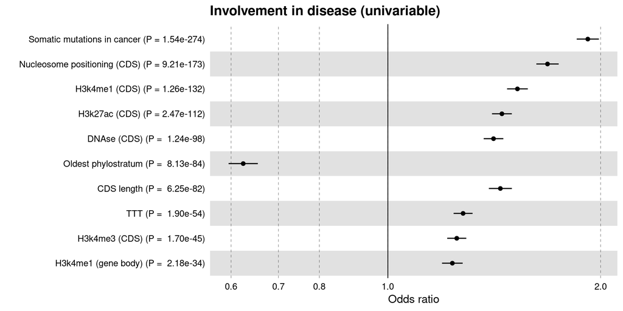

As explained above, a negative coefficient for the oldest phylostratum indicates that evolutionarily older genes are more likely to be involved in genetic diseases, in agreement with [1].

## 1.3 Multivariable analysis

Given the high level of collinearity between the genomic features (i.e. all features except somatic mutations and evolutionary age), they were transformed into principal components which were then used as independent variables in multivariable regression. Out of 80 genomic variables, 47 principal components were needed to explain 95% of the variance, and were used in multivariable regression. The rotation matrix from the original features to these 47 PCs is shown in the figure:

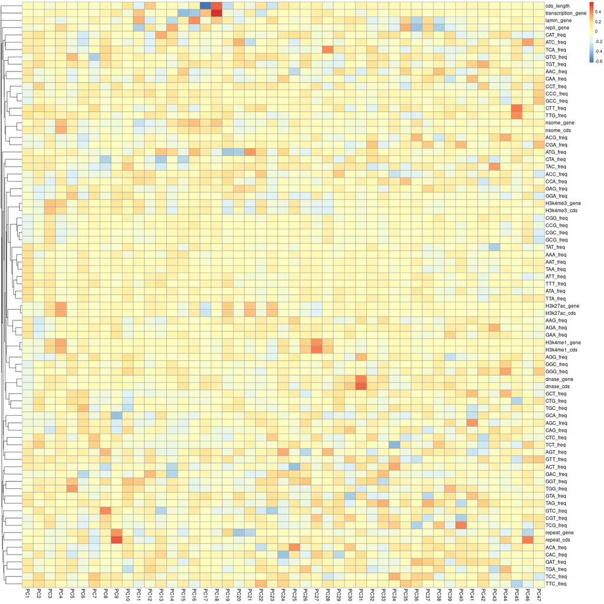

The model gives an AUC of 0.67. Significant overffitting can be excluded since the AUC obtained from 10-fold cross-validation is 0.663 (95% CI 0.654 - 0.672). Here the oldest phylostratum is considered as an integer, which might be questionable, but the results for somatic mutations adn PCs are essentially identical when the oldest phylostratum is treated as a categorical variable (not shown).

The table below shows the top 10 features by multivariable P-value (the top 3 variables by absolute loading are shown for each PC)

| predictor | beta | se | P | top_loadings |
| --- | --- | --- | --- | --- |
| oldest_phylostratum | -0.2826 | 0.02748 | 8.33e-25 |  |
| occ_total_sum | 0.3541 | 0.03572 | 3.647e-23 |  |
| PC3 | 0.08878 | 0.0107 | 1.054e-16 | CAG_freq, H3k4me3_cds, H3k4me3_gene |
| PC9 | -0.177 | 0.02189 | 6.315e-16 | repeat_cds, GCA_freq, repeat_gene |
| PC4 | 0.07135 | 0.01061 | 1.748e-11 | H3k27ac_gene, H3k4me1_gene, H3k27ac_cds |
| PC6 | -0.09727 | 0.01575 | 6.598e-10 | GAC_freq, TGC_freq, ATC_freq |
| PC1 | -0.02437 | 0.004084 | 2.415e-09 | GCC_freq, AAT_freq, ATT_freq |
| PC23 | -0.1188 | 0.02586 | 4.294e-06 | GTC_freq, cds_length, H3k27ac_cds |
| PC12 | 0.08849 | 0.01965 | 6.666e-06 | GAC_freq, cds_length, lamin_gene |
| PC46 | -0.1453 | 0.03557 | 4.436e-05 | repeat_cds, ATC_freq, repeat_gene |

This result demonstrates that evolutionary age and cancer somatic mutations are strong predictors of involvement in genetic diseases, largely independent of each other and from the genomic features considered. Specifically, old evolutionary age and high prevalence of somatic mutations in cancer are positively associated with involvement in genetic diseases.

The same results are shown in the figure

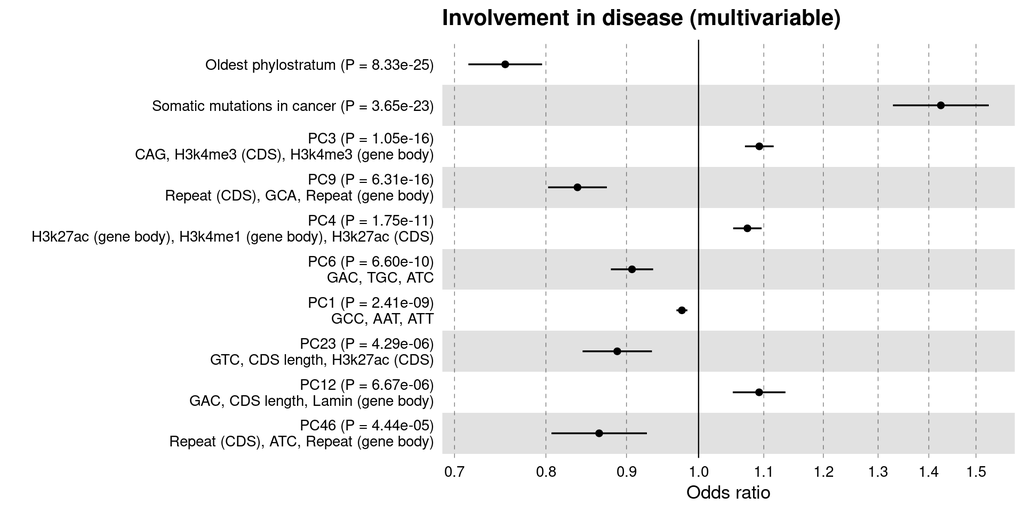

## 1.4 Specific phenotypes

The same multivariable analysis was applied to specific HPO phenotypes, namely all descendants of “abnormal phenotype” (HP:0000118) with a number of associated genes equal to at least 10 times the number of independent variables (i.e. 490 genes, to avoid overfitting). The table shows the beta coeffcients and P-values of evolutionary age and cancer somatic mutatons for each of these 258 phenotypes.

| name | c_age | p_age | c_mut | p_mut |
| --- | --- | --- | --- | --- |
| Abnormality of the digestive system | -0.3648 | 1.422e-21 | 0.3529 | 4.82e-18 |
| Abnormality of the skin | -0.1905 | 9.187e-07 | 0.3637 | 4.753e-17 |
| Localized skin lesion | -0.1651 | 0.004161 | 0.4658 | 1.505e-16 |
| Abnormality of skin morphology | -0.2241 | 4.513e-08 | 0.3622 | 1.706e-16 |
| Abnormality of the integument | -0.2364 | 9.924e-11 | 0.3337 | 2.326e-16 |
| Abnormality of immune system physiology | -0.133 | 0.00195 | 0.3853 | 3.802e-16 |
| Abnormality of the head | -0.3229 | 7.79e-20 | 0.3145 | 4.022e-16 |
| Abnormality of head or neck | -0.3189 | 1.184e-19 | 0.3086 | 1.079e-15 |
| Abnormality of the vasculature | -0.256 | 3.653e-09 | 0.362 | 1.828e-15 |
| Abnormality of the nervous system | -0.3759 | 2.232e-29 | 0.2924 | 3.12e-15 |

In agreement with the general results for “abnormal phenotype,” the coefficient of the oldest phylostratum is negative in 258/258 phenotypes, and the coefficient of cancer somatic mutations is positive in 258/258. Evolutionary age and cancer somatic mutations are significant independent predictors of involvement in disease in 258/258 and 253/258 phenotypes, respectively.

## 1.5 Specific tumor types

We analyzed association of the “abnormal phenotype” HPO annotation with the number of somatic mutations detected in specific tumors, instead of summed over all TCGA samples, together with evolutionary age and the same PCs of the genomic features used above.

Somatic mutations in 28/32 tumors were significantly associated (P <0.05) with involvement in abnormal phenotype, and the coefficient was positive in 28/28 of these cases. The following table shows the top 10 tumor types by P-value:

| tumor | beta | P |
| --- | --- | --- |
| UCEC | 0.3028 | 3.438e-23 |
| COAD | 0.2207 | 1.214e-20 |
| STAD | 0.2088 | 5.407e-15 |
| PAAD | 0.1857 | 3.756e-12 |
| BRCA | 0.2095 | 2.513e-10 |
| READ | 0.1346 | 3.491e-10 |
| BLCA | 0.1386 | 1.231e-09 |
| LGG | 0.2223 | 1.002e-07 |
| OV | 0.1579 | 2.076e-07 |
| UCS | 0.09488 | 7.772e-07 |

The figure shows coefficients and P-values for all tumor types:

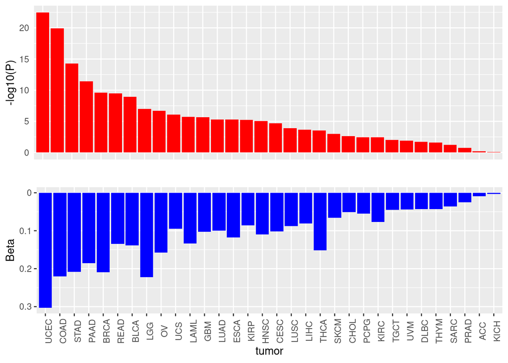

while these are the top independent predictors for the model using somatic mutations in UCEC:

| predictor | beta | P | top_loadings |
| --- | --- | --- | --- |
| oldest_phylostratum | -0.273 | 2.203e-23 |  |
| UCEC | 0.3028 | 3.438e-23 |  |
| PC9 | -0.18 | 9.758e-17 | repeat_cds, GCA_freq, repeat_gene |
| PC3 | 0.08049 | 7.828e-15 | CAG_freq, H3k4me3_cds, H3k4me3_gene |
| PC1 | -0.02958 | 2.077e-12 | GCC_freq, AAT_freq, ATT_freq |
| PC6 | -0.0986 | 3.035e-10 | GAC_freq, TGC_freq, ATC_freq |
| PC4 | 0.06356 | 1.268e-09 | H3k27ac_gene, H3k4me1_gene, H3k27ac_cds |
| PC23 | -0.1386 | 4.056e-08 | GTC_freq, cds_length, H3k27ac_cds |
| PC12 | 0.09563 | 8.315e-07 | GAC_freq, cds_length, lamin_gene |
| PC15 | -0.08658 | 2.524e-05 | transcription_gene, CTA_freq, AAC_freq |

Both the regression coefficient of somatic mutations and the associated P-value are strongly correlated with the number of genes found mutated at least once in each tumor type, as shown in the following figures (in the scond figure, “sig” is -log10 of the P-value).

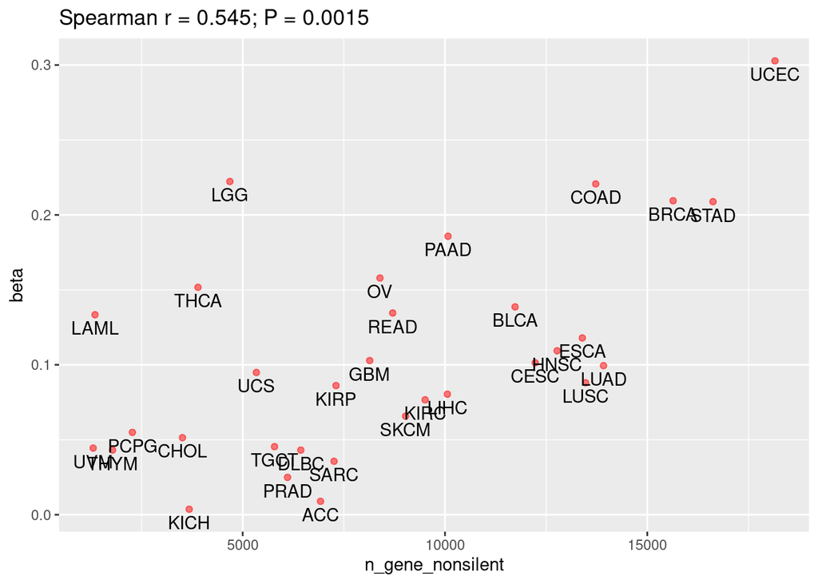

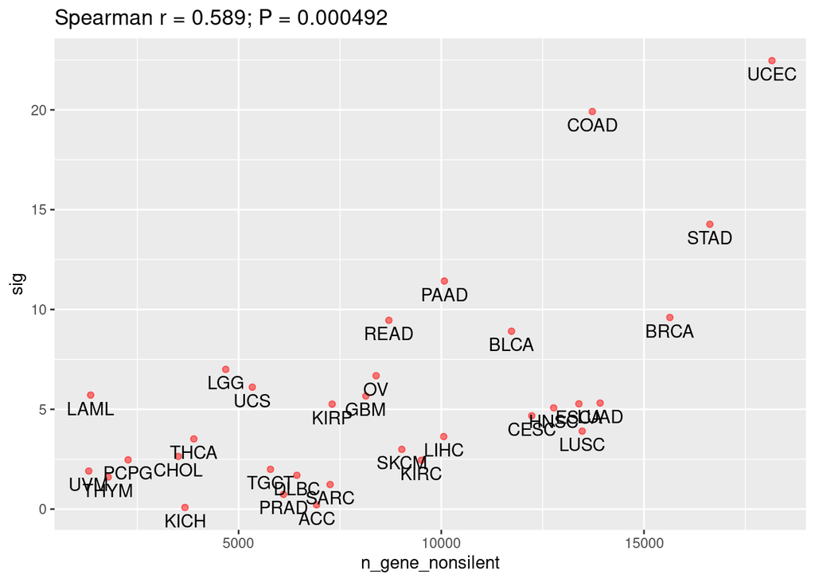

# References

1.

Domazet-Loso T, Tautz D. An ancient evolutionary origin of genes associated with human genetic diseases. Mol Biol Evol. 2008;25: 2699–2707. doi:10.1093/molbev/msn214

2.

Domazet-Loso T, Tautz D. Phylostratigraphic tracking of cancer genes suggests a link to the emergence of multicellularity in metazoa. BMC Biol. 2010;8: 66. doi:10.1186/1741-7007-8-66

3.

Neme R, Tautz D. Phylogenetic patterns of emergence of new genes support a model of frequent de novo evolution. BMC Genomics. 2013;14: 117. doi:10.1186/1471-2164-14-117

4.

Michaelson JJ, Shi Y, Gujral M, Zheng H, Malhotra D, Jin X, et al. Whole-genome sequencing in autism identifies hot spots for de novo germline mutation. Cell. 2012;151: 1431–1442. doi:10.1016/j.cell.2012.11.019